# Lecture 5: Exercises

October 11th, 2018

```r
library(tidyverse)
```

# Exercise 1: Data Manipulation

## Part 1: The map functions from `purrr`

1. Use `purrr` functions to find the column means for `mtcars` dataset. Note that the mean performance cars in this dataset is very poor. That’s because these models are from the 70s!
2. Use `purrr` functions to generate 10 random normals for each of the mean parameter: $\mu = -18, 5, 10, 30$.
3. What is the difference between running ``map(1:5, runif)` `map(list(1:5), rnorm)`, `map(list(1, 2, 3, 4, 5), rnorm)` and `map(1:5, rnorm, n = 5)`?
4. For looping over multiple arguments you can use `map2()` or `pmap()` function. Use `map2()` to generate 5 random numbers with for each pair of mean, and standard devtaion equal to: `c(2, 1), c(-3, 10), c(20, 0.1), c(-17, 2)`.

## Part 2: Merging

1. Identify the keys in the following datasets (you might need to install some packages and read some documentation):
- `Lahman::Batting`
- `nasaweather::atmos`
- `ggplot2::diamonds`
2. Add the location (i.e. the lat and lon) of the destination airport  
   to `flights` dataset from `nycflights13` package. Then, construct a new data table `mean_delay` containing information on the average arrival delay for each destination airport and its location (i.e. the lat and lon). Remember that some of the records are missing, so use `na.rm = TRUE` when computing means.

## Part 3: Export datasets

1. Export the `mean_delay` data as a ‘.tsv’ file. Save it on your “Desktop” then check the file was properly saved, then delete it.
2. Check what objects are currently stored in your environment using `ls()`. Save `mean_delay` as a R object using `saveRDS()` function to save it as am ‘.rds’ file. Then, select 2 different objects from the environment and use `save()` to save them to an ‘.rda’ file. Then, remove these objects and the `mean_delay` tibble. Check that you can reload these objects from files you saved.

# Exercise 2: Exploratory Data Analysis

Zillow provides data on home prices, including median rental price per square feet and the median estimated home value. There are many more statistics provided by zillow in [this website](https://www.zillow.com/research/data/) that you can explore.

```r
zillow_url1 <- paste0("http://files.zillowstatic.com/research/public/City/",
                    "City_MedianRentalPricePerSqft_AllHomes.csv")
zillow_url2 <- paste0("http://files.zillowstatic.com/research/public/City/",
                      "City_ZriPerSqft_AllHomes.csv")
price_per_sqft <- read_csv(zillow_url1)
value_per_sqft <- read_csv(zillow_url2)
```

```r
# First, we tidy the datasets:
price_per_sqft <- price_per_sqft %>%
    select(-Metro) %>%
    gather(`2010-01`:`2018-08`, key = "date", value = "price")
value_per_sqft <- value_per_sqft %>%
    select(RegionID:CountyName, `2011-01`:`2018-08`) %>%
    gather(`2011-01`:`2018-08`, key = "date", value = "value")
# Do the inner join:
home_per_sqft <- price_per_sqft %>%
    inner_join(value_per_sqft)
# Format dates:
home_per_sqft <- home_per_sqft %>%
    mutate(date = paste0(date, "-01"),
           date = as.Date(date))
# We filter to only top 10 priciest states this year
# excluding DC and HI:
top10_States <- home_per_sqft %>%
    filter(date >= as.Date("2018-01-01")) %>%
    filter(State != "HI", State != "DC") %>%
    group_by(State) %>%
    summarise(price = mean(price, na.rm = TRUE)) %>%
    top_n(10)
home_per_sqft <- home_per_sqft %>%
    filter(State %in% top10_States$State)
#rm(price_per_sqft, value_per_sqft)
```

The most expensive states by median home price per sq. ft. are:

```r
top10_States$State
```

```
 [1] "CA" "CO" "CT" "MA" "MD" "ME" "NH" "NJ" "NY" "RI"
```

1. For the current year (2018), using the filtered `home_per_sqft` dataset show the relationship between the value and the price per square foot of homes in 10 chosen states. The value is a dollar-denominated and estimated by Zillow.
- Is there a correlation between the price and the value per square foot?
- Are there any atypical trends you observe?
- Are there any clusters of regions that are pricier than, expected based on their estimated value? Find, the `RegionName` for an example these outliers, and see if it makes sense.
- Are there any clusters of regions that have higher value than, expected based on how cheap they are? Find, the `RegionName` for an example of these outliers, and see if it makes sense.
2. Collapse the data by computing the average of the median home price per square foot for each (state, date) pair. Then show the price trend over time for each of the top 10 states.
3. Now, subset your `home_per_sqft` dataset to homes located in the Bay Area:

```r
bayarea_counties <- c("Alameda", "Napa", "Santa Clara", "Contra Costa",
                      "San Francisco", "Solano", "Marin", "San Mateo",
                      "Sonoma")
bay_area_home <- home_per_sqft %>%
    filter(CountyName %in% bayarea_counties)
```

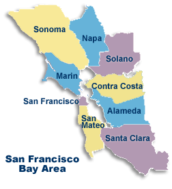

Filter your observations to the once after “2013-09-01”. Then generate a boxplot of home prices per square foot for the following regions:

```r
cities <- c("Oakland", "San Francisco", "Berkeley", "San Jose",
            "San Mateo", "Redwood City", "Mountain View", "Napa",
            "South San Francisco", "Menlo Park", "Cupertino")
```

For which region were the median home prices per square foot highest over the most recent 5 years period?

4. For the same regions plot the prices over time.

If you are curious, you can repeat this type of analysis for the listing prices of home sales using the following files from zillow: ‘City_MedianListingPricePerSqft_AllHomes.csv’, ‘City_Zhvi_AllHomes.csv’.

# Exercise 3: Interactive graphics with `plotly`

First generate the following (x,y,z) coordinates for your scatter 3D plot:

```r
library(plotly)
theta <- 2 * pi * runif(1000)
phi <- pi * runif(1000)
x <- sin(phi) * cos(theta)
y <- sin(phi) * sin(theta)
z <- cos(phi)
dat <- data.frame(x, y, z)
```

1. Generate a scatter plot with (x, y, z) coordinates, just computed. What do you observe?
2. Now generate new points as follows.

```r
N <- 10
theta <- rep(2*pi * seq(0, 1, length.out = 100), N)
phi <- rep(pi * seq(0, 1, length.out = N*100))
x <- sin(phi) * cos(theta)
y <- sin(phi) * sin(theta)
z <- cos(phi)
dat <- data.frame(x, y, z)
```

Then, use `plotly` to create a 3D scatter point plot and a separate line plot. Color the points by their ordering in the data-frame.